# B站“低创“视频创作者识别

### 狗熊会

为了吸引更多的视频创作者，提供更多种类、质量更好的作品，B站于2018年提出了创作者激励计划。然而，为了进入激励计划，部分用户通过对网络素材的简单拼接和编辑来大规模生产视频，从而快速获得高播放量。这些用户被称为“低创”用户。“低创”用户的出现使得B站视频质量严重下降。因此，本案例将采用聚类方法对B站用户进行细分，在识别出“低创”用户的同时深入了解其他用户的特点，从而对用户做到“精准激励”，达到视频质量和内容升级的目的。

本案例的学习目标包括：

（1）学习使用聚类分析的方法对用户进行细分

（2）学习如何在Python中对数据进行描述分析

（3）学习如何在Python中进行k-prototypes聚类分析

## 准备工作：

```python
# 加载所需库
import numpy as np # 基本数据处理需要的两个库
import pandas as pd
import matplotlib.pyplot as plt # 画图所需要的两个库
import seaborn as sns
from sklearn import preprocessing  # 数据因子化
from kmodes.kprototypes import KPrototypes # kprototypes聚类库
# 图像显示中文字体
plt.rcParams["font.family"] = 'Arial Unicode MS'
# 设置图像基本格式
sns.set(context='paper',
        style='dark',
        palette=sns.color_palette('muted',desat=1),
        color_codes=False)
```

## 任务一：数据读入

请阅读readme.txt了解数据中各个变量的含义，然后使用pandas里面的read_csv命令读入数据。读入数据后，由于聚类模型需要输入变量值为数值，因此我们需要进一步把里面的“性别”和“生日”两个离散型变量进行因子化处理。最后，使用pandas里面的describe函数对数据进行基本的描述统计分析。

```python
data1 = pd.read_csv('data.txt') # 读入数据


##  数据处理（因子化）

def data_process(data1):

    # 性别因子化
    encoder = preprocessing.LabelEncoder()  # 将encoder代表数值编码的函数（会将类别转为正整数）
    data1['sex'] = encoder.fit_transform(data1['sex']) # 进行转化
    data1['sex'] = data1['sex'].astype('object') # 将变量sex变为因子变量

    # 生日因子化
    f = lambda x:x[:2]  # 由于生日原始格式为09-19 这里我们只要月份信息，因此只取前两个即可
    data1['birthday'] = data1['birthday'].apply(f)  # 将函数f应用到birthday的每一条数据
    data1['birthday'] = data1['birthday'].astype(int).astype('object') # 数据原本格式为字符格式，这里先转为整型再转为因子

    return data1


data1 = data_process(data1)
```

查看数据基本统计信息

```python
data1[['following','fans','view','likes','album','article','video','audio']].describe()
# 这里['following','fans','views','likes']为连续变量
```

|  | following | fans | view | likes | album | article | video | audio |
| --- | --- | --- | --- | --- | --- | --- | --- | --- |
| count | 32157.000000 | 3.215700e+04 | 3.215700e+04 | 3.215700e+04 | 32157.000000 | 32157.000000 | 32157.000000 | 32157.000000 |
| mean | 144.889635 | 2.895899e+03 | 3.958446e+05 | 9.743245e+03 | 5.753802 | 0.433809 | 14.686569 | 0.180334 |
| std | 206.993529 | 5.536073e+04 | 8.556682e+06 | 2.059005e+05 | 61.124475 | 11.327101 | 117.770714 | 3.497263 |
| min | 0.000000 | 0.000000e+00 | 1.000000e+00 | 1.000000e+00 | 0.000000 | 0.000000 | 0.000000 | 0.000000 |
| 25% | 32.000000 | 1.000000e+00 | 7.946667e+02 | 3.333333e+00 | 0.000000 | 0.000000 | 0.000000 | 0.000000 |
| 50% | 80.000000 | 5.000000e+00 | 3.293000e+03 | 1.100000e+01 | 0.000000 | 0.000000 | 0.000000 | 0.000000 |
| 75% | 173.000000 | 3.600000e+01 | 1.704070e+04 | 6.500000e+01 | 1.000000 | 0.000000 | 4.000000 | 0.000000 |
| max | 2000.000000 | 4.335326e+06 | 1.141420e+09 | 1.712347e+07 | 5704.000000 | 1475.000000 | 11115.000000 | 334.000000 |

## 任务二：描述性分析

以“用户等级”为例进行描述性分析。B站的“创作者激励计划”是指：在B站中拥有1500个粉丝以上或视频播放总量15万以上的用户即可申请加入激励计划。可以看到，激励计划在“粉丝数”和“视频播放量”两个指标上对用户有要求。因此，请在本任务中探究“用户等级”与“粉丝数”、“视频播放量”两个指标的关系。你可以使用分组箱线图来完成这个分析，并对两个统计图进行解读。(由于“粉丝数”，“视频播放量”不同用户之间差距巨大，可以使用对数变换之后的数据进行箱线图展示)

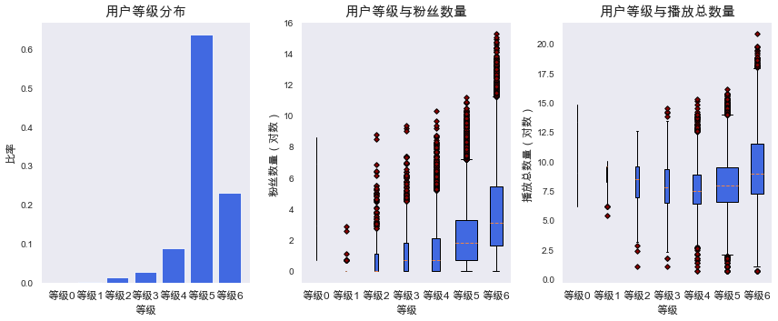

```python
# 设置图片显示字体
plt.rcParams["font.family"] = 'Arial Unicode MS'
# 通过level变量分组，并统计每一个组的样本数量
numy = data1.groupby('level').size()
# numx 存储level的值
numx = numy.index
label = numx
# 设置图像的大小
plt.figure(figsize=(12,5))
# 设置一个1行3列的图，最后一个1表示第1张图片
plt.subplot(131)
# 生成柱状图
plt.bar(numx,numy/sum(numy),align='center',color='royalblue',tick_label=label)
plt.ylabel('比率',size=12) # 设置y轴名称与大小
plt.xlabel('等级',size=12) # 设置x轴名称与大小
plt.xticks(numx,['等级'+str(int(i)) for i in numx],size=12) # 设置x轴标签名称与大小
plt.yticks(size=10) # 设置y轴标签大小
plt.title('用户等级分布',size=15) # 图像名称与大小

# 第2张图
plt.subplot(132)
# fans_level 用来存储每一个等级类别的粉丝数据，用于之后相线图展示
fans_level=[]
for i in numx:
    fans_level.append(np.log(data1['fans'][data1['level']==i]+1))

plt.boxplot(fans_level,patch_artist='red',showcaps=True,showfliers=True,meanline=False,
            # 这个是边缘的颜色 箱子的颜色
            boxprops={'color':'black','facecolor':'royalblue'} ,
            # 这个是点的颜色
            flierprops={'marker':'D','markerfacecolor':'darkred','markersize':4},
            meanprops={'marker':'D','markerfacecolor':'yellow',',arkersize':4},
            medianprops={'linestyle':'--'},
            labels=['等级'+str(int(i)) for i in numx], # 设置箱子底部的名称
            widths=np.sqrt(np.array([len(i) for i in fans_level]))/200 # 根据每个类别的数据量，设置箱子宽度，数据量大的宽度大
             )
plt.ylabel('粉丝数量（对数）',size=12)
plt.xlabel('等级',size=12)
plt.xticks(size=12)
plt.yticks(size=10)
plt.title('用户等级与粉丝数量',size=15)

# 第3张图的解释看第2张图
plt.subplot(133)
fans_level=[]
for i in numx:
    fans_level.append(np.log(data1['view'][data1['level']==i]+1))

plt.boxplot(fans_level,patch_artist='red',showcaps=True,showfliers=True,meanline=False,
            # 这个是边缘的颜色 箱子的颜色
            boxprops={'color':'black','facecolor':'royalblue'} ,
            # 这个是点的颜色
            flierprops={'marker':'D','markerfacecolor':'darkred','markersize':4},
            meanprops={'marker':'D','markerfacecolor':'yellow',',arkersize':4},
            medianprops={'linestyle':'--'},
            labels=['等级'+str(int(i)) for i in numx],
            widths=np.sqrt(np.array([len(i) for i in fans_level]))/200
             )
plt.ylabel('播放总数量（对数）',size=12)
plt.xlabel('等级',size=12)
plt.xticks(size=12)
plt.yticks(size=10)
plt.title('用户等级与播放总数量',size=15)
plt.tight_layout()
plt.show()
```

```
【解读参考】：
```

在用户等级上，等级为 5、 6 的用户数量明显高于其他等级，这里由于用户数据是按照用户的id依次爬取，因而数据中的用户均是B站成立初期的用户，从而出现用户等级在 5，6 中数量非常多的现象。从后两张图中可见，B 站中的用户等级是根据用户在 B 站的活跃程度进行评级的一个结果，因此越活跃的用户往往具有越多的粉丝或者越多的播放量。通过描述分析可以看到，用户等级可以作为一个区别用户类别的变量。

## 任务三：生成衍生指标

根据原始数据生成四个衍生指标，即获赞率、粉丝留存率、播放量、作品总数。每个衍生指标的具体计算方法如下：

粉丝留存率 = 粉丝数/视频播放量

获赞率 = 获赞数/视频播放量

平均播放量 = 作品总播放量/总作品数

总作品数 = 用户作品的加和

生成衍生指标之后，请使用直方图展示获赞率、粉丝留存率、播放量三个变量的分布情况。你可以先尝试绘制原始取值的分布情况，你会发现这三个变量都是严重右偏的。为此，可以对各个变量取对数之后，再绘制直方图。根据各个直方图，你能发现什么？

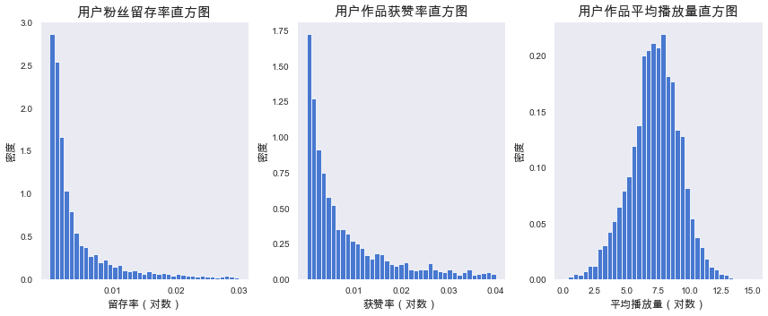

```python
data1['wpr'] = ((data1['likes']+1)/data1['view']) # 有些获赞量为0，之后对数变换会有问题，因而均加一处理
data1['ftr'] = ((data1['fans']+1)/data1['view'])
data1['apr'] = data1['view']/(data1['album']+data1['article']+data1['video']+data1['audio']+1) # 总作品量可能为0，因此也加一处理
data1['sum'] = data1['album']+data1['article']+data1['video']+data1['audio']



plt.rcParams["font.family"] = 'Arial Unicode MS'
plt.figure(figsize=(12,5))

binss = np.linspace(0,3,40)
plt.subplot(131)
# bins 直方图的间隔，histtype直方图种类，density展示的是直方图的密度
plt.hist(np.log(data1['ftr']+1)*100,bins=binss,histtype='barstacked',density=True)
plt.title('用户粉丝留存率直方图',size=15)
plt.xlabel('留存率（对数）',size=12)
plt.ylabel('密度',size=12)
plt.yticks(size=10)
plt.xticks([1,2,3],[0.01,0.02,0.03])
plt.xticks(size=10)

plt.subplot(132)
binss = np.linspace(0,4,40)
plt.hist(np.log(data1['wpr']+1)*100,bins=binss,histtype='barstacked',density=True)
plt.title('用户作品获赞率直方图',size=15)
plt.xlabel('获赞率（对数）',size=12)
plt.ylabel('密度',size=12)
plt.yticks(size=10)
plt.xticks([1,2,3,4],[0.01,0.02,0.03,0.04])
plt.xticks(size=10)


plt.subplot(133)
binss = np.linspace(0,15,40)
plt.hist(np.log(data1['apr']+1),bins=binss,histtype='barstacked',density=True)
plt.title('用户作品平均播放量直方图',size=15)
plt.xlabel('平均播放量（对数）',size=12)
plt.ylabel('密度',size=12)
plt.yticks(size=10)
plt.xticks(size=10)
plt.tight_layout()
```

```
【解读参考】：
```

对数变换后，用户粉丝留存率和获赞率仍然呈现明显的右偏分布，但用户平均播放量呈现对称分布的特点。

## 任务四：建立聚类模型

聚类之后，展示四个类别在'获赞率','粉丝留存率','均播放量','粉丝人数','播放量','获赞数','总作品数'7个变量上的类别中心取值。

```python
# 聚类之前，将存在空值的数据去掉（之前填充的只有获赞量与播放量）
data1=data1.dropna(axis=0,how='any')

# 三类变量需要不同的处理方式，以下三个变量用于存储他们的名称以便之后提取这些变量
# 离散变量名称（类别型）
qualitative = ['sex','types','level','birthday']
# 连续变量名称（计数型）
numerical = ['following','fans','view','likes','album','article','video','audio','sum']
# 连续变量名称
continuous = ['wpr','ftr','apr']

# 提取三类变量
data_qual = data1[qualitative]
data_nume = data1[numerical]
data_conti = data1[continuous]

# 将离散变量转为int型（聚类模型要求离散变量的格式）
ints = lambda x:x.astype(int) # ints函数将数据列x转为int型
data_qual = data_qual.apply(ints) # apply函数使ints函数遍历data_qual中的列
# 将整数变量与连续变量均采取对数变换
log = lambda x:np.log(x+1) # log函数 将数据列x的每一个数据转为ln(x_i+1) 因为data_nume为计数型的数据，存在0值，所以这里+1
logs = lambda x:np.log(x)  # logs函数 将数据列x的每一个数据转为ln(x_i)
data_nume = data_nume.apply(log)
data_conti = data_conti.apply(logs)
# 连接三类数据，并重置数据索引
data = pd.concat([data_conti,data_nume,data_qual],axis=1) # 这里将离散变量连在了最后，列的索引为12，13，14，15
data.index = range(len(data)) # 重置索引


# 定义模型 4个类别，算法采用Huang提出的算法，n_jobs代表模型运行时调用所有的计算机cpu能使用的线程（一般情况下速度会变快）
kp = KPrototypes(n_clusters=4, init='Huang',n_jobs=-1)
# 指定离散变量位置（位置用的索引），并训练模型
clusters = kp.fit_predict(data,categorical=[12,13,14,15])
```

| 用户类别 | 获赞率 | 粉丝留存率 | 均播放量 | 粉丝人数 | 播放量 | 获赞数 | 总作品数 |
| --- | --- | --- | --- | --- | --- | --- | --- |
| 第一类用户 | 0.001 | 0.001 | 1825 | 2 | 2250 | 9 | 4 |
| 第二类用户 | 0.03 | 0.02 | 114 | 5 | 235 | 7 | 2 |
| 第三类用户 | 0.01 | 0.004 | 5800 | 893 | 232288 | 2150 | 40 |
| 第四类用户 | 0.002 | 0.002 | 3552 | 15 | 9940 | 18 | 4 |

## 任务五：类别解读

为了观察每类用户的特点，我们可以通过雷达图展示各个类别在某些重点变量上的取值特点。具体来说，我们可以选取：'获赞率','粉丝留存率','均播放量','粉丝人数','播放量','获赞数','总作品数'共七个变量的类中心情况进行展示。对于任意一个变量，首先对其在四个类别的类中心取值进行“最小最大值”的标准化处理，即(x-min)/(max-min)，这样各个类中心取值都在0~1之间变动，从而方便的在雷达图中进行对比。

绘制各个类在上述7个变量上的雷达图，然后根据雷达图的情况，概括总结每个类的特点。（Hint: 可根据上表数据做雷达图）

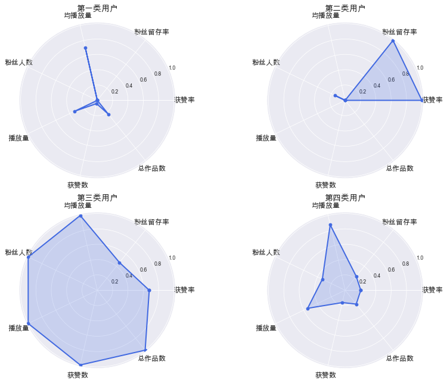

```python
# dat存储四类用户的聚类中心，与上面表格数据是一致的
dat = np.log(np.array([[0.001,0.001,1825,2,2250,9,4],
[0.03,0.02,114,5,235,7,2],
[0.01,0.004,5800,893,232288,2150,40],
[0.002,0.002,3552,15,9940,18,4]]))

# 将数据标准化处理
for i in range(len(dat[0])):
    dat[:,i] = (dat[:,i]-np.min(dat[:,i]))/(np.max(dat[:,i])-np.min(dat[:,i]))
# types存储用户名称
types = ['第一类用户','第二类用户','第三类用户','第四类用户']

# labels存储雷达图的各个标签名称
labels=np.array(['获赞率','粉丝留存率','均播放量','粉丝人数','播放量','获赞数','总作品数'])
nAttr=len(labels)

plt.rcParams["font.family"] = 'Arial Unicode MS'
plt.figure(figsize=(12,9))

for i in range(4):
    number = 221+i # 第i张图位置
    plt.subplot(number,polar=True) # polar=True 表示使用雷达图
    Python=dat[i] # 第i个用户的数据
    angles=np.linspace(0,2*np.pi,nAttr,endpoint=False) # angle表示雷达图的角度
    Python=np.concatenate((Python,[Python[0]])) # 与自己第一个数据连接起来，相当于形成一个环（雷达图要求首尾数据是相同的）
    angles=np.concatenate((angles,[angles[0]]))

    plt.plot(angles,Python,'bo-',color='royalblue',linewidth=2) # bo代表数据点，点的形式，linewidth代表线的宽度
    plt.fill(angles,Python,facecolor='royalblue',alpha=0.2) # 雷达图内部的颜色填充，alpha代表颜色的透明度
    plt.thetagrids(angles*180/np.pi,labels,size=12)
    plt.ylim([0,1.02]) # 如果0，1图像的某些点会超出显示范围，因此尽量范围大于1
    plt.grid(True) # 加网格
    plt.title(types[i],size=14)

plt.tight_layout()
plt.show()
```

```
【解读参考】：
```

第一类用户呈现高播放量，低粉丝数，低获赞率，低粉丝留存率的特点，符合之前分析的大部分“低创”用户的特点，其粉丝留存率与获赞率并不高，将这一类用户称为“低创“用户。

第三类用户具有超高播放量，超高粉丝量。其作品数量较多，质量也呈现了参差不齐的情况，因而这一类用户在获赞率与粉丝留存率上并不一定很高，将这一类用户称为 up 主用户。

## 任务六：附加题

为了更直观的展示四类用户的特点，重点考察粉丝数、播放量、粉丝留存率、获赞率四个判定“低创”用户的重要变量在四类用户上的分布情况。你可以绘制两张散点图，分别是：粉丝数（对数）V.S.播放量（对数），粉丝留存率（对数）V.S.获赞率（对数）。在每个图中，各个类别用户的散点可以用不同颜色标记出来，相应的类别中心可以用某种特殊形状的符号（比如五角星）标记。这样，我们就能非常清晰的看到每类用户在上述几个变量上的分布情况。从这两个图中，你能得到哪些结论？

[figure not shown]

```python
n=1000
np.random.seed(1) # 为了重现图像，设置随机种子
index = np.random.choice(range(len(data)), size=n, replace=False) # 原数据集太大无法全部展示，因而从原始数据中抽取1000个样本

# 设置每一类的颜色
map_colors={0:'r',1:'purple',2:'deepskyblue',3:'limegreen'}
# color存储每一个点的颜色
color = list(map(lambda x: map_colors[x], clusters[index]))

plt.rcParams["font.family"] = 'Arial Unicode MS'
plt.figure(figsize=(8,8))
plt.subplot(211)
plt.scatter(data['view'][index],data['fans'][index],c=color,s=10,alpha=0.5,label='') # s控制点的大小
plt.ylabel('粉丝数（对数）',size=15)
plt.xlabel('播放量（对数）',size=15)

## 画每一类的聚类中心
# kp.cluster_centroids_[0][0][5] 存储第一类用户获赞率的聚类中心
plt.scatter(kp.cluster_centroids_[0][0][5],kp.cluster_centroids_[0][0][4],
            color='darkred',marker='*',s=200,label='up主用户')
plt.scatter(kp.cluster_centroids_[0][1][5],kp.cluster_centroids_[0][1][4],
            color='indigo',marker='*',s=200,label='“低创”用户')
plt.scatter(kp.cluster_centroids_[0][2][5],kp.cluster_centroids_[0][2][4],
            color='teal',marker='*',s=200,label='过渡用户')
plt.scatter(kp.cluster_centroids_[0][3][5],kp.cluster_centroids_[0][3][4],
            color='darkgreen',marker='*',s=200,label='高质量用户')
plt.legend(title='聚类中心',fontsize=12)
plt.xticks(size=12)
plt.yticks(size=12)
plt.title('粉丝量与播放量聚类结果',size=20)



plt.subplot(212)
plt.scatter(data['wpr'][index],data['ftr'][index],c=color,s=10,alpha=0.5,label='')
plt.ylabel('粉丝留存率（对数）',size=15)
plt.xlabel('获赞率（对数）',size=15)

plt.scatter(kp.cluster_centroids_[0][0][0],kp.cluster_centroids_[0][0][1],
            color='darkred',marker='*',s=200,label='up主用户')
plt.scatter(kp.cluster_centroids_[0][1][0],kp.cluster_centroids_[0][1][1],
            color='indigo',marker='*',s=200,label='“低创”用户')
plt.scatter(kp.cluster_centroids_[0][2][0],kp.cluster_centroids_[0][2][1],
            color='teal',marker='*',s=200,label='过渡用户')
plt.scatter(kp.cluster_centroids_[0][3][0],kp.cluster_centroids_[0][3][1],
            color='darkgreen',marker='*',s=200,label='高质量用户')
plt.legend(title='聚类中心',fontsize=12)
plt.xticks(size=12)
plt.yticks(size=12)
plt.title('粉丝留存率与获赞率聚类结果',size=20)
plt.tight_layout()
```

[output not shown]